# Lab3

Author

Nicole Tang

# Learning Goals

- Read in and get familiar with the meteorology dataset
- Step through the EDA “checklist” presented in the class slides
- Practice making exploratory graphs

As you do this, think about what questions you would like to ask regarding this data. What would you ask a collaborator who was more familiar with it?

# Lab Description

We will work with the meteorological data presented in lecture. Recall the dataset consists of weather station readings in the continental US.

**The objectives of the lab are to find the weather station with the highest elevation and look at patterns in the time series of its wind speed and temperature.**

# 1. Read in the data

First download and then read in with `data.table::fread()`. This is slightly faster than some of the more common functions, such as `read.table`, but it produces a different type of object, which is why we need to convert it into a `data.frame` after reading it in.

# 2. Check the dimensions, headers, footers.

How many columns, rows are there? Some useful functions for this are `dim`, `head`, and `tail`.

**There are 30 columns and 2377343 rows.**

```r
dim(met)
```

```
[1] 2377343      30
```

```r
head(met)
```

```
  USAFID  WBAN year month day hour min  lat      lon elev wind.dir wind.dir.qc
1 690150 93121 2019     8   1    0  56 34.3 -116.166  696      220           5
2 690150 93121 2019     8   1    1  56 34.3 -116.166  696      230           5
3 690150 93121 2019     8   1    2  56 34.3 -116.166  696      230           5
4 690150 93121 2019     8   1    3  56 34.3 -116.166  696      210           5
5 690150 93121 2019     8   1    4  56 34.3 -116.166  696      120           5
6 690150 93121 2019     8   1    5  56 34.3 -116.166  696       NA           9
  wind.type.code wind.sp wind.sp.qc ceiling.ht ceiling.ht.qc ceiling.ht.method
1              N     5.7          5      22000             5                 9
2              N     8.2          5      22000             5                 9
3              N     6.7          5      22000             5                 9
4              N     5.1          5      22000             5                 9
5              N     2.1          5      22000             5                 9
6              C     0.0          5      22000             5                 9
  sky.cond vis.dist vis.dist.qc vis.var vis.var.qc temp temp.qc dew.point
1        N    16093           5       N          5 37.2       5      10.6
2        N    16093           5       N          5 35.6       5      10.6
3        N    16093           5       N          5 34.4       5       7.2
4        N    16093           5       N          5 33.3       5       5.0
5        N    16093           5       N          5 32.8       5       5.0
6        N    16093           5       N          5 31.1       5       5.6
  dew.point.qc atm.press atm.press.qc       rh
1            5    1009.9            5 19.88127
2            5    1010.3            5 21.76098
3            5    1010.6            5 18.48212
4            5    1011.6            5 16.88862
5            5    1012.7            5 17.38410
6            5    1012.7            5 20.01540
```

```r
tail(met)
```

```
        USAFID  WBAN year month day hour min    lat      lon elev wind.dir
2377338 726813 94195 2019     8  31   18  56 43.650 -116.633  741       NA
2377339 726813 94195 2019     8  31   19  56 43.650 -116.633  741       70
2377340 726813 94195 2019     8  31   20  56 43.650 -116.633  741       NA
2377341 726813 94195 2019     8  31   21  56 43.650 -116.633  741       10
2377342 726813 94195 2019     8  31   22  56 43.642 -116.636  741       10
2377343 726813 94195 2019     8  31   23  56 43.642 -116.636  741       40
        wind.dir.qc wind.type.code wind.sp wind.sp.qc ceiling.ht ceiling.ht.qc
2377338           9              C     0.0          5      22000             5
2377339           5              N     2.1          5      22000             5
2377340           9              C     0.0          5      22000             5
2377341           5              N     2.6          5      22000             5
2377342           1              N     2.1          1      22000             1
2377343           1              N     2.1          1      22000             1
        ceiling.ht.method sky.cond vis.dist vis.dist.qc vis.var vis.var.qc temp
2377338                 9        N    16093           5       N          5 30.0
2377339                 9        N    16093           5       N          5 32.2
2377340                 9        N    16093           5       N          5 33.3
2377341                 9        N    14484           5       N          5 35.0
2377342                 9        N    16093           1       9          9 34.4
2377343                 9        N    16093           1       9          9 34.4
        temp.qc dew.point dew.point.qc atm.press atm.press.qc       rh
2377338       5      11.7            5    1013.6            5 32.32509
2377339       5      12.2            5    1012.8            5 29.40686
2377340       5      12.2            5    1011.6            5 27.60422
2377341       5       9.4            5    1010.8            5 20.76325
2377342       1       9.4            1    1010.1            1 21.48631
2377343       1       9.4            1    1009.6            1 21.48631
```

# 3. Take a look at the variables.

Show the type (class) of each variable (hint: try the `str` function).

```r
str(met)
```

```
'data.frame':   2377343 obs. of  30 variables:
 $ USAFID           : int  690150 690150 690150 690150 690150 690150 690150 690150 690150 690150 ...
 $ WBAN             : int  93121 93121 93121 93121 93121 93121 93121 93121 93121 93121 ...
 $ year             : int  2019 2019 2019 2019 2019 2019 2019 2019 2019 2019 ...
 $ month            : int  8 8 8 8 8 8 8 8 8 8 ...
 $ day              : int  1 1 1 1 1 1 1 1 1 1 ...
 $ hour             : int  0 1 2 3 4 5 6 7 8 9 ...
 $ min              : int  56 56 56 56 56 56 56 56 56 56 ...
 $ lat              : num  34.3 34.3 34.3 34.3 34.3 34.3 34.3 34.3 34.3 34.3 ...
 $ lon              : num  -116 -116 -116 -116 -116 ...
 $ elev             : int  696 696 696 696 696 696 696 696 696 696 ...
 $ wind.dir         : int  220 230 230 210 120 NA 320 10 320 350 ...
 $ wind.dir.qc      : chr  "5" "5" "5" "5" ...
 $ wind.type.code   : chr  "N" "N" "N" "N" ...
 $ wind.sp          : num  5.7 8.2 6.7 5.1 2.1 0 1.5 2.1 2.6 1.5 ...
```

[output cut: 16 more lines]

What are the names of the key variables related to our question of interest?

**Key variables include: elev, wind.sp, temp, year, day, hour**

# 4. Take a closer look at the key variables.

```r
table(met$year)
```

```
   2019
2377343
```

```r
table(met$day)
```

```
    1     2     3     4     5     6     7     8     9    10    11    12    13
75975 75923 76915 76594 76332 76734 77677 77766 75366 75450 76187 75052 76906
   14    15    16    17    18    19    20    21    22    23    24    25    26
77852 76217 78015 78219 79191 76709 75527 75786 78312 77413 76965 76806 79114
   27    28    29    30    31
79789 77059 71712 74931 74849
```

```r
table(met$hour)
```

```
     0      1      2      3      4      5      6      7      8      9     10
 99434  93482  93770  96703 110504 112128 106235 101985 100310 102915 101880
    11     12     13     14     15     16     17     18     19     20     21
100470 103605  97004  96507  97635  94942  94184 100179  94604  94928  96070
    22     23
 94046  93823
```

```r
summary(met$temp)
```

```
   Min. 1st Qu.  Median    Mean 3rd Qu.    Max.    NA's
 -40.00   19.60   23.50   23.59   27.80   56.00   60089
```

```r
summary(met$elev)
```

```
   Min. 1st Qu.  Median    Mean 3rd Qu.    Max.
  -13.0   101.0   252.0   415.8   400.0  9999.0
```

```r
summary(met$wind.sp)
```

```
   Min. 1st Qu.  Median    Mean 3rd Qu.    Max.    NA's
   0.00    0.00    2.10    2.46    3.60   36.00   79693
```

It looks like the elevation variable has observations with 9999.0, which is probably an indicator for missing. We should take a deeper look at the [data dictionary](https://github.com/USCbiostats/data-science-data/blob/master/02_met/met-datadictionary.pdf) to confirm. The wind speed variable is OK but there is a lot of missing data.

After checking the data we should make the appropriate modifications. Replace elevations with 9999 as `NA`.

```r
met$elev[met$elev==9999.0] <- NA
summary(met$elev)
```

```
   Min. 1st Qu.  Median    Mean 3rd Qu.    Max.    NA's
    -13     101     252     413     400    4113     710
```

At what elevation is the highest weather station?

**The max elevation is: 4113**

We also have the issue of the minimum temperature being -40C, which seems implausible, so we should remove those observations.

```r
met <- met[met$temp > -40, ]
head(met[order(met$temp), ])
```

```
        USAFID WBAN year month day hour min    lat    lon elev wind.dir
1203053 722817 3068 2019     8   1    0  56 38.767 -104.3 1838      190
1203055 722817 3068 2019     8   1    1  56 38.767 -104.3 1838      180
1203128 722817 3068 2019     8   3   11  56 38.767 -104.3 1838       NA
1203129 722817 3068 2019     8   3   12  56 38.767 -104.3 1838       NA
1203222 722817 3068 2019     8   6   21  56 38.767 -104.3 1838      280
1203225 722817 3068 2019     8   6   22  56 38.767 -104.3 1838      240
        wind.dir.qc wind.type.code wind.sp wind.sp.qc ceiling.ht ceiling.ht.qc
1203053           5              N     7.2          5         NA             9
1203055           5              N     7.7          5         NA             9
1203128           9              C     0.0          5         NA             9
1203129           9              C     0.0          5         NA             9
1203222           5              N     2.6          5         NA             9
1203225           5              N     7.7          5         NA             9
        ceiling.ht.method sky.cond vis.dist vis.dist.qc vis.var vis.var.qc
1203053                 9        N       NA           9       N          5
1203055                 9        N       NA           9       N          5
1203128                 9        N       NA           9       N          5
1203129                 9        N       NA           9       N          5
1203222                 9        N       NA           9       N          5
1203225                 9        N       NA           9       N          5
         temp temp.qc dew.point dew.point.qc atm.press atm.press.qc rh
1203053 -17.2       5        NA            9        NA            9 NA
1203055 -17.2       5        NA            9        NA            9 NA
1203128 -17.2       5        NA            9        NA            9 NA
1203129 -17.2       5        NA            9        NA            9 NA
1203222 -17.2       5        NA            9        NA            9 NA
1203225 -17.2       5        NA            9        NA            9 NA
```

There are still some suspiciously low values for temperature (-17.2C), but we will deal with those later.

We should also check the wind speed variable for any abnormalities.

How many missing values are there in the `wind.sp` variable?

**There are 91832 missing values for wind.sp**

```r
summary(met$wind.sp)
```

```
   Min. 1st Qu.  Median    Mean 3rd Qu.    Max.    NA's
   0.00    0.00    2.10    2.46    3.60   36.00   91832
```

# 5. Check the data against an external data source.

We should check the suspicious temperature value (where is it located?) and validate that the range of elevations make sense (-13m to 4113m).

Google is your friend here.

Fix any problems that arise in your checks.

Where was the location for the coldest temperature readings (-17.2C)? Do these seem reasonable in context?

**The -17.2C address is Sanborn Road, Yoder, CO 80864 which is about 26.6 C on average in month 8 so it doesn’t make sense**

Does the range of values for elevation make sense? Why or why not?

**The Min is -17.2C and the Max is 33.90C for an elevation of 1838. The min does not appear to be ormal the the max seems about right.**

```r
summary(met$temp[met$lat == 38.767 & met$lon == -104.3])
```

```
   Min. 1st Qu.  Median    Mean 3rd Qu.    Max.    NA's
 -17.20   15.00   19.80   20.10   25.95   33.90   60089
```

# 6. Calculate summary statistics

Remember to keep the initial question in mind. We want to pick out the weather station with maximum elevation and examine its wind speed and temperature.

Some ideas: select the weather station with maximum elevation; look at the correlation between temperature and wind speed; look at the correlation between temperature and wind speed with hour and day of the month.

```r
elev <- met[which(met$elev == max(met$elev, na.rm = TRUE)), ]
summary(elev)
```

```
     USAFID            WBAN          year          month        day
 Min.   :720385   Min.   :419   Min.   :2019   Min.   :8   Min.   : 1.0
 1st Qu.:720385   1st Qu.:419   1st Qu.:2019   1st Qu.:8   1st Qu.: 8.0
 Median :720385   Median :419   Median :2019   Median :8   Median :16.0
 Mean   :720385   Mean   :419   Mean   :2019   Mean   :8   Mean   :16.1
 3rd Qu.:720385   3rd Qu.:419   3rd Qu.:2019   3rd Qu.:8   3rd Qu.:24.0
 Max.   :720385   Max.   :419   Max.   :2019   Max.   :8   Max.   :31.0

      hour            min             lat            lon              elev
 Min.   : 0.00   Min.   : 6.00   Min.   :39.8   Min.   :-105.8   Min.   :4113
 1st Qu.: 6.00   1st Qu.:13.00   1st Qu.:39.8   1st Qu.:-105.8   1st Qu.:4113
 Median :12.00   Median :36.00   Median :39.8   Median :-105.8   Median :4113
 Mean   :11.66   Mean   :34.38   Mean   :39.8   Mean   :-105.8   Mean   :4113
 3rd Qu.:18.00   3rd Qu.:53.00   3rd Qu.:39.8   3rd Qu.:-105.8   3rd Qu.:4113
 Max.   :23.00   Max.   :59.00   Max.   :39.8   Max.   :-105.8   Max.   :4113

    wind.dir     wind.dir.qc        wind.type.code        wind.sp
 Min.   : 10.0   Length:2117        Length:2117        Min.   : 0.000
 1st Qu.:250.0   Class :character   Class :character   1st Qu.: 4.100
 Median :300.0   Mode  :character   Mode  :character   Median : 6.700
 Mean   :261.5                                         Mean   : 7.245
 3rd Qu.:310.0                                         3rd Qu.: 9.800
 Max.   :360.0                                         Max.   :21.100
 NA's   :237                                           NA's   :168
  wind.sp.qc          ceiling.ht    ceiling.ht.qc   ceiling.ht.method
 Length:2117        Min.   :   30   Min.   :5.000   Length:2117
 Class :character   1st Qu.: 2591   1st Qu.:5.000   Class :character
 Mode  :character   Median :22000   Median :5.000   Mode  :character
                    Mean   :15145   Mean   :5.008
                    3rd Qu.:22000   3rd Qu.:5.000
                    Max.   :22000   Max.   :9.000
                    NA's   :4
   sky.cond            vis.dist     vis.dist.qc          vis.var
 Length:2117        Min.   :    0   Length:2117        Length:2117
 Class :character   1st Qu.:16093   Class :character   Class :character
 Mode  :character   Median :16093   Mode  :character   Mode  :character
                    Mean   :15913
                    3rd Qu.:16093
                    Max.   :16093
                    NA's   :683
  vis.var.qc             temp         temp.qc            dew.point
 Length:2117        Min.   : 1.00   Length:2117        Min.   :-6.0000
 Class :character   1st Qu.: 6.00   Class :character   1st Qu.: 0.0000
 Mode  :character   Median : 8.00   Mode  :character   Median : 0.0000
                    Mean   : 8.13                      Mean   : 0.8729
                    3rd Qu.:10.00                      3rd Qu.: 2.0000
                    Max.   :15.00                      Max.   : 7.0000

 dew.point.qc         atm.press     atm.press.qc       rh
 Length:2117        Min.   : NA    Min.   :9     Min.   :53.63
 Class :character   1st Qu.: NA    1st Qu.:9     1st Qu.:58.10
 Mode  :character   Median : NA    Median :9     Median :61.39
                    Mean   :NaN    Mean   :9     Mean   :60.62
                    3rd Qu.: NA    3rd Qu.:9     3rd Qu.:61.85
                    Max.   : NA    Max.   :9     Max.   :70.01
                    NA's   :2117
```

Note that to find the maximum elevation, we had to add `na.rm = TRUE`, because the elevation variable contains missing values. This is an example of how missing values can quickly propagate throughout an analysis (as the “maximum” of `1`, `2`, and `NA` is `NA`, because it cannot be defined).

Also note that we used the `which` function to tell us which elements of the logical comparison are `TRUE`. We did this because some of them were `NA`, which can lead to issues when subsetting by a logical variable.

```r
cor(elev$temp, elev$wind.sp, use="complete")
```

```
[1] -0.09373843
```

```r
cor(elev$temp, elev$hour, use="complete")
```

```
[1] 0.4397261
```

```r
cor(elev$wind.sp, elev$day, use="complete")
```

```
[1] 0.3643079
```

```r
cor(elev$wind.sp, elev$hour, use="complete")
```

```
[1] 0.08807315
```

```r
cor(elev$temp, elev$day, use="complete")
```

```
[1] -0.003857766
```

The `use="complete"` argument is another thing we added to avoid compounding `NA`s.

# 7. Exploratory graphs

We should look at the distributions of all of the key variables to make sure there are no remaining issues with the data.

### **Use the `hist` function to make histograms of the elevation, temperature, and wind speed variables for the whole dataset**

Look at where the weather station with highest elevation is located.

```r
library(leaflet)
leaflet(elev) |>
  addProviderTiles('OpenStreetMap') |>
  addCircles(lat=~lat,lng=~lon, opacity=1, fillOpacity=1, radius=100)
```

[interactive chart not shown]

Look at the time series of temperature and wind speed at this location. For this we will need to create a date-time variable for the x-axis.

```r
library(lubridate)
elev$date <- with(elev, ymd_h(paste(year, month, day, hour, sep= ' ')))
summary(elev$date)
```

```
                      Min.                    1st Qu.
"2019-08-01 00:00:00.0000" "2019-08-08 11:00:00.0000"
                    Median                       Mean
"2019-08-16 22:00:00.0000" "2019-08-16 14:09:56.8823"
                   3rd Qu.                       Max.
"2019-08-24 11:00:00.0000" "2019-08-31 22:00:00.0000"
```

```r
elev <- elev[order(elev$date), ]
head(elev)
```

```
       USAFID WBAN year month day hour min  lat      lon elev wind.dir
221697 720385  419 2019     8   1    0  36 39.8 -105.766 4113      170
221698 720385  419 2019     8   1    0  54 39.8 -105.766 4113      100
221699 720385  419 2019     8   1    1  12 39.8 -105.766 4113       90
221700 720385  419 2019     8   1    1  35 39.8 -105.766 4113      110
221701 720385  419 2019     8   1    1  53 39.8 -105.766 4113      120
221702 720385  419 2019     8   1    2  12 39.8 -105.766 4113      120
       wind.dir.qc wind.type.code wind.sp wind.sp.qc ceiling.ht ceiling.ht.qc
221697           5              N     8.8          5       1372             5
221698           5              N     2.6          5       1372             5
221699           5              N     3.1          5       1981             5
221700           5              N     4.1          5       2134             5
221701           5              N     4.6          5       2134             5
221702           5              N     6.2          5      22000             5
       ceiling.ht.method sky.cond vis.dist vis.dist.qc vis.var vis.var.qc temp
```

[output cut: 20 more lines]

With the date-time variable we can plot the time series of temperature and wind speed.

Use the `plot` function to make line graphs of temperature vs. date and wind speed vs. date

**Plot: Temperature vs. Date**

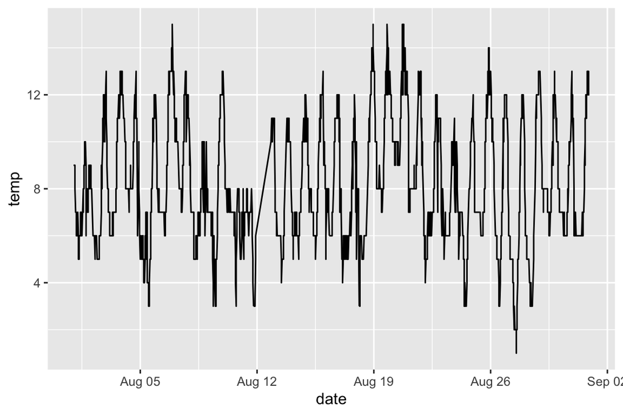

```r
plot <- elev %>%
  ggplot(aes(
    x = date,
    y = temp
  ))+
  geom_line()

print(plot)
```

**Plot: Windspeed vs. Date**

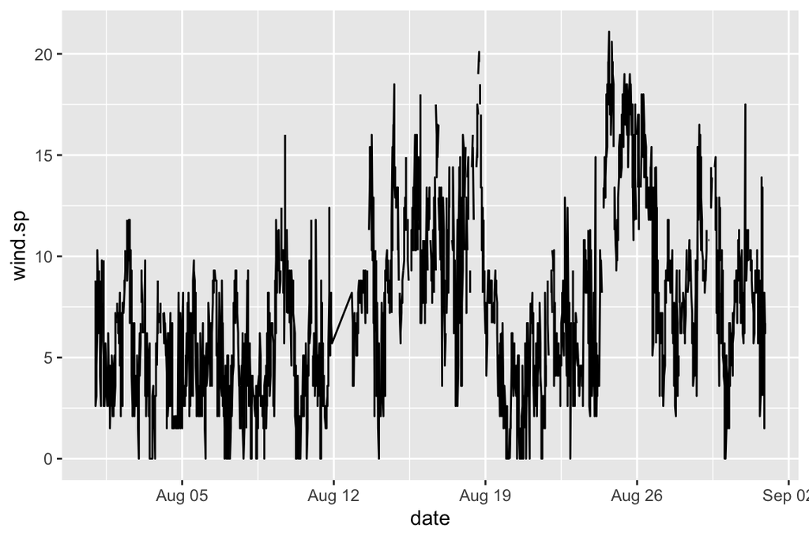

```r
plot2 <- elev %>%
  ggplot(aes(
    x = date,
    y = wind.sp
  )) +
  geom_line()

print(plot2)
```

Summarize any trends that you see in these time series plots

# 8. Ask questions

By now, you might have some specific questions about how the data was gathered and what some of the different variables and values mean. Alternatively, maybe you have an idea for how some of the variable should be related and you want to explore that relationship. In a real-world analysis, these questions could potentially be answered by a collaborator, who may have been part of the team that collected the data.

What questions do you have about the data?

**I am curious if there is a way to look into global warming and climate change with this data. Whether looking at trends from year to year, or adding variables like UV index or rainfall. It would also be curious to see if years of el nino or la nina you can see in the graphs how the temperature and whether varies.**

If you haven’t already, now would be a good time to look at the accompanying [data dictionary](https://github.com/USCbiostats/data-science-data/blob/master/02_met/met-datadictionary.pdf) for this dataset and see if it can answer any of your questions. If you have questions about the nature of the dataset and how it was gathered, this might be able to help.

For questions about variables in the dataset or relationships between them, try making some more exploratory plots. Do you see the patterns you would expect?

**When considering variables like temperature or water I am curious to see if there would be any trends where you could identify if it affected food/crop growth and production. It would be interesting to see if there were impacts on the economy as well. Maybe years with higher temperatures result in higher electrical costs for things like air conditioning.**

There are many different types of summaries and visualization strategies that we have not discussed, but which could provide interesting perspectives on the data.

Some other useful plotting functions include: - `pairs` for making all pairwise scatter plots in a dataset with >2 dimensions. - `heatmap` and/or `corrplot` (from the `corrplot` package) for visualizing matrices in general or correlation matrices in particular. - `image` a low-level matrix visualization function - `barplot`, especially with `table`, for visualizing frequencies of categorical variables.